# Mountain Versus Man

A Student from Fall 2019

11/25/2019

# Introduction

For the novice climber or the decorated mountaineer, this project will uncover insights to better understand the relationship between mountain and man. The goal is to provide helpful decisions as to what peaks to choose from and the various factors that contribute to the success and fall of mountain climbers.

To explore this relationship, I will be utilizing data about climbers fatalities from, 8000ers.com,The top 125 topgraphic mountain dataset and a similiar dataset with various factors both from Kaggle.My approach is to make analysis and insights on the two datasets about mountains. I will then take a closer look at the relationship between climber fatalities and the analyzed data on mountains by joining these datasets. The goal here is to see if I can uncover new information in the data that isn’t clear and use it to explain our key findings.

Thus with this approach I hope my analysis can give climbers, enthusiasts, and anyone in between a clear understanding of what peaks to climb, when to climb, etc and all the various factors to contribute to a successful summit.

# Packages Required

```r
library(tibble) # used to create tibbles
library(tidyr) # used to tidy up data
library(rmarkdown) # dynamic document
library(pdftools) # used for text mining pdf files
library(ggplot2) # used for data visualization
library(dplyr) # used for data manipulation
library(shiny)# used for showing dynamic visuals in collaboration with ggvis
library(prettydoc)# used for creating pretty documents from R markdown
library(knitr)#for dynamic report generation
library(ggvis)#easy to build interactive graphics for exploratory data analysis
library(RColorBrewer)#Creates nice looking color palettes especially for thematic maps
library(treemap)# Treemap Visualization
library(tidyverse)# multiple tidy up data packages here
```

# Import Data & Preparation

**Source of the data**

**1) The 125 most topographically prominent summits data** https://www.kaggle.com/justynapxw/the-125-most-topographically-prominent-summits I sourced this data from the kaggle public datasets. It was collected by Justyna Pawlata on 10/19 who sourced it from wikipedia. The purpose of this dataset was to help and analysze summits and ranges on earth.

```
## [1] 140
```

```
## [1] "No..ID"         "Peak"           "Range"          "Location"
## [5] "Prominence..m." "Height..m."     "Col..m."        "Parent"
```

| Peak.ID | Peak | RangeName | Location | Prominence..m. | Height..m. | Col..m. | ParentPeak |
| --- | --- | --- | --- | --- | --- | --- | --- |
| 1 | Mount Everest | Himalayas | Nepal | 8848 | 8848 | 0 | None |
| 1 | Mount Everest | Himalayas | China | 8848 | 8848 | 0 | None |
| 2 | Aconcagua | Andes | Argentina | 6962 | 6962 | 0 | None |
| 3 | Denali | Alaska Range | United States | 6144 | 6191 | 47 | Aconcagua |
| 4 | Mount Kilimanjaro | Eastern Rift mountains | Tanzania | 5885 | 5895 | 10 | Everest |
| 5 | Pico Cristóbal Colón | Sierra Nevada de Santa Marta | Colombia | 5509 | 5700 | 191 | Aconcagua |

**Variable Names and meaning:** **Peak.Id -Number of the peak,** **Peak-Name of the peak,** **RangeName- Range the peak belongs to,** **Location- Country (countries) the peak belongs to,** **Prominence (m)-Prominence,** **Height (m)-Height of the peak,** **ParentPeak- peak in the higher terrain (connected to the peak by the col),** **Col (m) - Col of the peak,**

**2) List of Highest Mountains in the world data** https://en.wikipedia.org/wiki/List_of_highest_mountains_on_Earth I sourced this data from the kaggle public datasets, however the source was removed .It was sourced from wikipedia. The purpose of this dataset was to help and analysze summits and ranges on earth.Another dataset with thats similar but with added variables and specific to the Himalayas and Karakoram Range.

| Rank | Peak | Height_m | Height_ft | Prominence_m | RangeName | Coordinates | ParentPeak | Year_First_Ascent | Ascent | Failed_attempts |
| --- | --- | --- | --- | --- | --- | --- | --- | --- | --- | --- |
| 1 | Mount Everest | 8848 | 29029 | 8848 | Mahalangur Himalaya | 27°59′17″N 86°55′31″E | none | 1953 | ≫145 | 121 |
| 2 | K2 | 8611 | 28251 | 4020 | Baltoro Karakoram | 35°52′53″N 76°30′48″E | Mount Everest | 1954 | 45 | 44 |
| 3 | Kangchenjunga | 8586 | 28169 | 3922 | Kangchenjunga Himalaya | 27°42′12″N 88°08′51″E * | Mount Everest | 1955 | 38 | 24 |
| 4 | Lhotse | 8516 | 27940 | 610 | Mahalangur Himalaya | 27°57′42″N 86°55′59″E | Mount Everest | 1956 | 26 | 26 |
| 5 | Makalu | 8485 | 27838 | 2378 | Mahalangur Himalaya | 27°53′23″N 87°05′20″E | Mount Everest | 1955 | 45 | 52 |
| 6 | Cho Oyu | 8188 | 26864 | 2340 | Mahalangur Himalaya | 28°05′39″N 86°39′39″E | Mount Everest | 1954 | 79 | 28 |

**Variable Names and definition:** **Rank -Number of the peak** **Peak-Name of the peak,** **RangeName- Range the peak belongs to,** **Coordinates- Coordinates of peak location,** **Prominence_m -Prominence in meters,** **Height_m-Height of the peak in meters,** **Height_ft-Height of the peak in feet,** **ParentPeak- peak in the higher terrain (connected to the peak by the col),** **Ascent- The number of ascents,** **Year_First_Ascent- Year the peak was first summitted,** **Failed_attempts- failed attempts before 2004,** **Col (m) - Col of the peak**

**3) 8000ers-seasons-with-most-fatalities** https://www.8000ers.com/cms/en/download.html?func=select&id=4 I sourced this data from the 8000ers.com. It was collected by Eberhard Jurgaiski on 09/24/2012 & 8000ers.com The purpose of this dataset is to understand the relationship with the seasons on varoius mountains and the amount of climbers deaths.

| Year.of.Death | Season | Peak | Fatalities | Nationality | Number.of.Females |
| --- | --- | --- | --- | --- | --- |
| 1972 | PRE MONSOON | Manaslu | 4 | Korean | 0 |
| 1972 | PRE MONSOON | Manaslu | 1 | Japanese | 0 |
| 1972 | PRE MONSOON | Manaslu | 10 | Nepalese Sherpa | 0 |
| 1972 | PRE MONSOON | Manaslu | 2 | Austrian | 0 |
| 1937 | SUMMER | Nanga Parbat | 7 | German | 0 |
| 1937 | SUMMER | Nanga Parbat | 9 | Indian Sherpa | 0 |

**Variable Names and definition:** **year.of.death-year climbers passed away,** **season- season at the time of the death,** **Peak- Name of the peak,** **Fatalities- Number of the fatalities,** **Nationality- Nationality of the deceased,** **and Number.of.Females- number of females in the group.**

# Exploratory Data Analysis and Visualization

**I added a new column callled Region to show the region on which the peaks are located.**

| Peak.ID | Peak | RangeName | Location | Prominence..m. | Height..m. | Col..m. | ParentPeak | Region |
| --- | --- | --- | --- | --- | --- | --- | --- | --- |
| 1 | Mount Everest | Himalayas | Nepal | 8848 | 8848 | 0 | None | Asia |
| 1 | Mount Everest | Himalayas | China | 8848 | 8848 | 0 | None | Asia |
| 2 | Aconcagua | Andes | Argentina | 6962 | 6962 | 0 | None | South America |
| 3 | Denali | Alaska Range | United States | 6144 | 6191 | 47 | Aconcagua | North America |
| 4 | Mount Kilimanjaro | Eastern Rift mountains | Tanzania | 5885 | 5895 | 10 | Everest | Africa |
| 5 | Pico Cristóbal Colón | Sierra Nevada de Santa Marta | Colombia | 5509 | 5700 | 191 | Aconcagua | South America |

**Which Mountain range has the most peaks in this sample?** The Range with the most peaks, are the Himalayas with a max of 11 for first dataset.

| RangeName | n |
| --- | --- |
| Himalayas | 11 |
| Andes | 7 |
| Java | 5 |
| Saint Elias Mountains | 4 |
| Eastern Rift mountains | 3 |
| Karakoram | 3 |

| RangeName | n |
| --- | --- |
| Mahalangur Himalaya | 12 |
| Baltoro Karakoram | 10 |
| Hispar Karakoram | 10 |
| Dhaulagiri Himalaya | 7 |
| Kangchenjunga Himalaya | 7 |
| Garhwal Himalaya | 6 |

**What is the highest peak and Where is the highest peak Located, and height in meters?** The highest peak is Mount Everest at 8,848 meters and it is located in Nepal and China in Asia.

| Peak | Height..m. | Location | Region |
| --- | --- | --- | --- |
| Mount Everest | 8848 | Nepal | Asia |
| Mount Everest | 8848 | China | Asia |
| K2 | 8611 | China | Asia |

**Top Highest 10 Topgraphic Mountains** The World’s top 10 highest mountains in meters.

| Peak | Height..m. |
| --- | --- |
| Mount Everest | 8848 |
| K2 | 8611 |
| Kanchenjunga | 8586 |
| Dhaulagiri | 8167 |
| Manaslu | 8163 |
| Nanga Parbat | 8125 |
| Annapurna | 8091 |
| Shishapangma | 8027 |
| Nanda Devi | 7816 |
| Batura Sar | 7795 |

**Parent Peaks** *A visualization of all the Peaks without Parent peak and the sub peaks below them.* The words on top of the boxes are all the peaks that are parents to the peaks in boxes. The box on the top left has no parent peak.

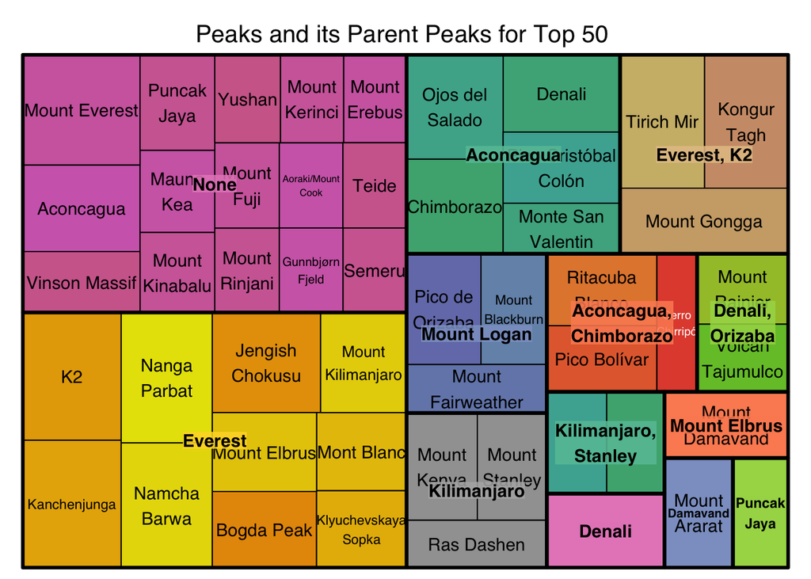

**What are the highest Peaks for each region?**

This information is particularly useful for anyone looking to climb the highest peak for each region or the seven continents.

*Note there is a dispute as to whether Mount Blanc or Mount Elbrus is the highest peak in Europe. The answer depends on what the interpreter’s defintion of what a continent is and where it’s borders lie. The border between Asia and Europe can be defined by many as the caucaus mountains or the Kuma_Manycn depression. If the border is defined by the depression then Mount Blanc is the highest peak in Europe. If it’s defined otherwise then it’s in Asia, and this is the widely accepted as correct. Thus, Mount Elbrus is on the European continent and highest in Europe.

| Peak | Height..m. | Region |
| --- | --- | --- |
| Mount Everest | 8848 | Asia |
| Aconcagua | 6962 | South America |
| Chimborazo | 6263 | Central America & Carribean |
| Denali | 6191 | North America |
| Mount Kilimanjaro | 5895 | Africa |
| Mount Elbrus | 5642 | Europe |
| Mount Damavand | 5610 | Middle East |
| Vinson Massif | 4892 | Antarctica |
| Puncak Jaya | 4884 | Oceania |

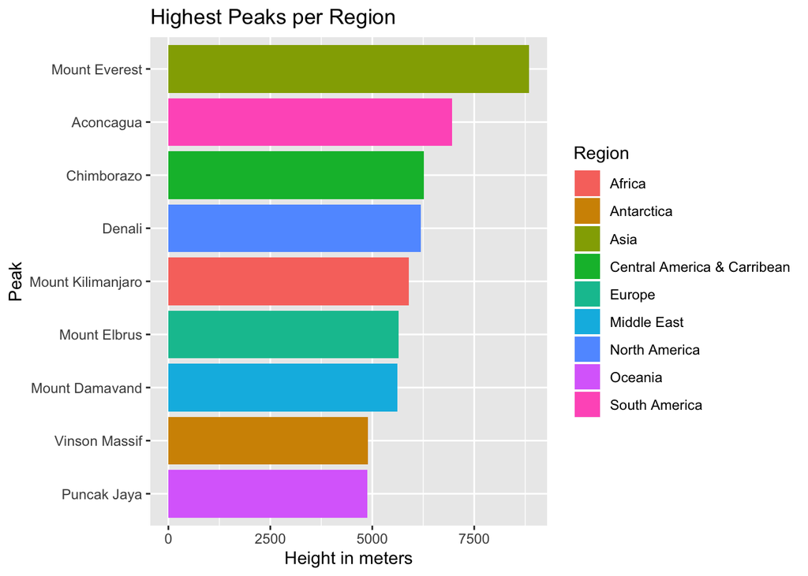

## The Highest Peaks in each country in the first sample.

| Location | Peak | Height..m. |
| --- | --- | --- |
| Afghanistan | Kuh-e Bandaka | 6812 |
| Antarctica | Vinson Massif | 4892 |
| Argentina | Aconcagua | 6962 |
| Bhutan | Gangkhar Puensum | 7570 |
| Brazil | Pico da Neblina | 2994 |
| Cameroon | Mount Cameroon | 4040 |
| Canada | Mount Logan | 5959 |
| Cape Verde | Mount Fogo | 2829 |
| Chad | Emi Koussi | 3445 |
| Chile | Ojos del Salado | 6893 |
| China | Mount Everest | 8848 |
| Colombia | Pico Cristóbal Colón | 5700 |
| Costa Rica | Cerro Chirripó | 3820 |
| Dominican Republic | Pico Duarte | 3098 |
| DR Congo | Mount Stanley | 5109 |
| Ecuador | Chimborazo | 6263 |
| Equatorial Guinea | Pico Basilé | 3011 |
| Ethiopia | Ras Dashen | 4550 |
| France | Mont Blanc | 4808 |
| Greenland | Gunnbjørn Fjeld | 3694 |
| Guatemala | Volcán Tajumulco | 4220 |
| India | Kanchenjunga | 8586 |
| Indonesia | Puncak Jaya | 4884 |
| Iran | Mount Damavand | 5610 |
| Italy | Mont Blanc | 4808 |
| Japan | Mount Fuji | 3776 |
| Kazakhstan | Pik Talgar | 4979 |
| Kenya | Mount Kenya | 5199 |
| Kyrgyzstan | Jengish Chokusu | 7439 |
| Madagascar | Maromokotro | 2876 |
| Malaysia | Mount Kinabalu | 4095 |
| Mexico | Pico de Orizaba | 5636 |
| Morocco | Toubkal | 4167 |
| Myanmar | Saramati | 3826 |
| Nepal | Mount Everest | 8848 |
| New Zealand | Aoraki/Mount Cook | 3724 |
| Oman | Jabal Shams | 3019 |
| Pakistan | K2 | 8611 |
| Papua New Guinea | Mount Wilhelm | 4509 |
| Philippines | Mount Apo | 2954 |
| Russia | Mount Elbrus | 5642 |
| Rwanda | Mount Karisimbi | 4507 |
| South Georgia | Mount Paget | 2934 |
| Spain | Teide | 3718 |
| Taiwan | Yushan | 3952 |
| Tajikistan | Ismoil Somoni Peak | 7495 |
| Tanzania | Mount Kilimanjaro | 5895 |
| Timor-Leste | Pico do Ramelau | 2963 |
| Turkey (in Arabic) | Mount Ararat | 5137 |
| Uganda | Mount Stanley | 5109 |
| United States | Denali | 6191 |
| Venezuela | Pico Bolívar | 4981 |
| Yemen | Jabal an Nabi Shu’ayb | 3666 |

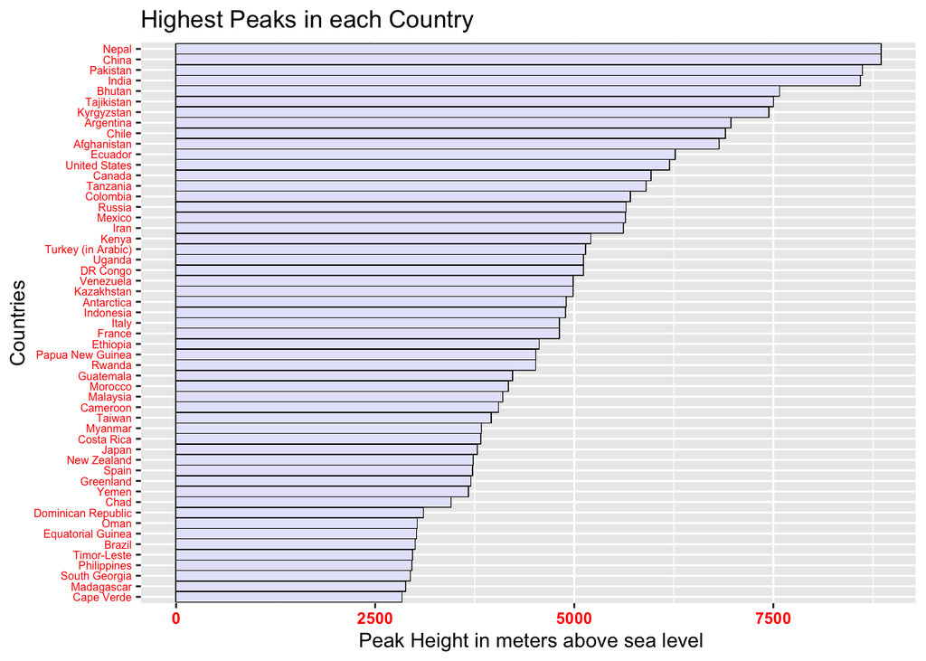

**What is the median height for peaks per country?** Finding the median height of a mountain for each country is useful for anyone wanting to climb in a particular country. The median was used here instead of the mean because the data can have some outliers and that would result in some unfair results, thus the median is used.

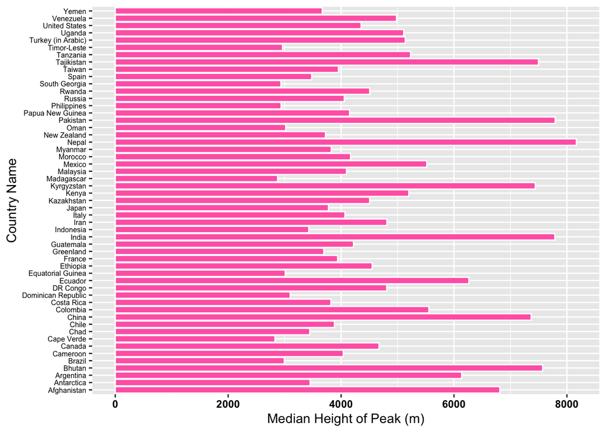

```r
median_peaks <- mountains%>% group_by(Location)%>%summarise(median_Height=median(`Height..m.`))


h<- ggplot(data = median_peaks,mapping = aes(x=Location, y = median_Height, )) +geom_col(color='white', fill='hotpink') + coord_flip()

h+theme(axis.text.x = element_text(face="bold", color="Black"),
   axis.text.y = element_text( color="Black",  size=6 ))+ labs(x="Country Name", y="Median Height of Peak (m)")
```

**The names of the highest peaks for each range in the sample.** *Turns out that The Himalayas Range (1) and Karakoram Range (2) are the top 2 ranges that contain the heights peaks. I subset this data to see what the average height for a peak on these ranges are and then will compare them to the avg from another dataset.*

| RangeName | Peak | Height..m. |
| --- | --- | --- |
| Himalayas | Mount Everest | 8848 |
| Karakoram | K2 | 8611 |
| Hindu Kush | Tirich Mir | 7708 |
| Kongur Shan | Kongur Tagh | 7649 |
| Daxue Mountains | Mount Gongga | 7556 |
| Pamir Mountains | Ismoil Somoni Peak | 7495 |

The average height of a mountain on the Himalayas Range is 8084.636 meters. Peak Gangkhar Puensum is the lowest peak at 7570 meters and Mount Everest is the highest at 8848m. The average Height of the Himalayas Range is 8,084.636 meters. Performing a t.test i was able to find the point estimate of the average peak height on the Himalayas.

```r
#Himalayas Range, 11 rows
avg_Himalayans<- mountains %>% select(Peak,Height..m.,RangeName)%>%filter(RangeName=="Himalayas")
unique(avg_Himalayans)%>%summarise(avg_Height=mean(Height..m.))
```

```
## # A tibble: 1 x 1
##   avg_Height
##        <dbl>
## 1      8085.
```

```r
# getting the true height of the avg mountains on the himalayas
true_height<-avg_Himalayans%>%select(Peak, Height..m.)
true_height<-unique(true_height)


t.test(true_height$Height..m.)
```

```
##
##  One Sample t-test
##
## data:  true_height$Height..m.
## t = 71.956, df = 10, p-value = 6.555e-15
## alternative hypothesis: true mean is not equal to 0
## 95 percent confidence interval:
##  7834.293 8334.980
## sample estimates:
## mean of x
##  8084.636
```

I was able to perform the same analysis here for the second sample and found a point estimate of the average height of a peak in the Himalayas to be,7612.033 meters.I was able to perform the same analysis again for the Karakoram range and found a point estimate of the average height of a peak to be,7544.265 meters. **Note that there may be some discrepancies in the analysis, as I filtered for ranges that end in Himalaya, because this dataset seems to categorize sub-ranges within the Himalayas range.

```r
#Himalayas Range
avg_Himalayans2<- summits%>%filter(endsWith(RangeName,"Himalaya"))
avg_Himalayans2
```

```
## # A tibble: 60 x 11
##     Rank Peak  Height_m Height_ft Prominence_m RangeName Coordinates
##    <int> <chr>    <int>     <int>        <int> <chr>     <chr>
##  1     1 Moun…     8848     29029         8848 Mahalang… 27°59′17″N…
##  2     3 Kang…     8586     28169         3922 Kangchen… 27°42′12″N…
##  3     4 Lhot…     8516     27940          610 Mahalang… 27°57′42″N…
##  4     5 Maka…     8485     27838         2378 Mahalang… 27°53′23″N…
##  5     6 Cho …     8188     26864         2340 Mahalang… 28°05′39″N…
##  6     7 Dhau…     8167     26795         3357 Dhaulagi… 28°41′48″N…
##  7     8 Mana…     8163     26781         3092 Manaslu … 28°33′00″N…
##  8     9 Nang…     8126     26660         4608 Nanga Pa… 35°14′14″N…
##  9    10 Anna…     8091     26545         2984 Annapurn… 28°35′44″N…
## 10    14 Shis…     8027     26335         2897 Jugal Hi… 28°21′12″N…
## # … with 50 more rows, and 4 more variables: ParentPeak <chr>,
## #   Year_First_Ascent <chr>, Ascent <chr>, Failed_attempts <int>
```

```r
#The average Height in this dataset for the Himalayas is 7612.033 m

t.test(avg_Himalayans2$Height_m)
```

```
##
##  One Sample t-test
##
## data:  avg_Himalayans2$Height_m
## t = 147.96, df = 59, p-value < 2.2e-16
## alternative hypothesis: true mean is not equal to 0
## 95 percent confidence interval:
##  7509.086 7714.981
## sample estimates:
## mean of x
##  7612.033
```

```r
# At a 95% confidence level the upper level:7509.086 and lower level:7714.981

avg_Karakoram2<- summits%>%filter(endsWith(RangeName,"Karakoram"))
avg_Karakoram2
```

```
## # A tibble: 49 x 11
##     Rank Peak  Height_m Height_ft Prominence_m RangeName Coordinates
##    <int> <chr>    <int>     <int>        <int> <chr>     <chr>
##  1     2 K2        8611     28251         4020 Baltoro … 35°52′53″N…
##  2    11 Gash…     8080     26509         2155 Baltoro … 35°43′28″N…
##  3    12 Broa…     8051     26414         1701 Baltoro … 35°48′38″N…
##  4    13 Gash…     8035     26362         1524 Baltoro … 35°45′28″N…
##  5    17 Gash…     7932     26024          712 Baltoro … 35°45′38″N…
##  6    19 Dist…     7884     25866         2525 Hispar K… 36°19′33″N…
##  7    21 Khun…     7823     25666         1765 Hispar K… 36°12′19″N…
##  8    22 Mash…     7821     25659         2457 Masherbr… 35°38′28″N…
##  9    25 Batu…     7795     25574         3118 Batura K… 36°30′37″N…
## 10    26 Kanj…     7790     25558         1660 Hispar K… 36°12′20″N…
## # … with 39 more rows, and 4 more variables: ParentPeak <chr>,
## #   Year_First_Ascent <chr>, Ascent <chr>, Failed_attempts <int>
```

```r
#The average Height in this dataset for the Karakoram is 7544.265 m

t.test(avg_Karakoram2$Height_m)
```

```
##
##  One Sample t-test
##
## data:  avg_Karakoram2$Height_m
## t = 181.65, df = 48, p-value < 2.2e-16
## alternative hypothesis: true mean is not equal to 0
## 95 percent confidence interval:
##  7460.758 7627.773
## sample estimates:
## mean of x
##  7544.265
```

```r
# At a 95% confidence level the upper level:7460.758 and lower level:7627.773
```

```r
#Two sided t. test
t.test(avg_Himalayans2$Height_m, mu=7612.033, alternative = "two.sided")
```

```
##
##  One Sample t-test
##
## data:  avg_Himalayans2$Height_m
## t = 6.479e-06, df = 59, p-value = 1
## alternative hypothesis: true mean is not equal to 7612.033
## 95 percent confidence interval:
##  7509.086 7714.981
## sample estimates:
## mean of x
##  7612.033
```

##Distribution of Prominence **The prominence of a peak is the height of the peak’s summit above the lowest contour line encircling it and no higher summit.** The smaller the prominence the greater the height. This shows that the major of mountains in this sample have a large prominence are thus not as high as believed.

```r
mountains %>% ggvis(~Prominence..m.,fill :="DarkBlue") %>% layer_densities() %>% add_axis("y",title_offset = 60)
```

[output not shown]

## Successful and Unsuccessful Climbs

**Are failed attempts proportionate to peak heights?** What is the cause of failed attempts for climbers? Is it the higher the Peak the higher the number of failed attempts? Or are other factors not taken into account here such as difficulty of peak, skill of climber, etc. Let’s take a look and perform a correlation analysis:

```r
# correlation analysis
cor(summits$Failed_attempts, summits$Height_m, use = "complete")
```

```
## [1] 0.7327838
```

```
## # A tibble: 1 x 1
##       n
##   <int>
## 1   413
```

```
## # A tibble: 1 x 1
##       n
##   <int>
## 1   559
```

Therefore since there are failed attempts for peaks greater than 8000 meters, it makes since that there would be a smaller number of ascents.Turns out that, this is the case.In the graph below fewer people have ascended to peaks greater than 8500 meters. I would also like to note that skilled climbers do not re-ascend peaks they have already completed, whereas beginners may do so to improve their skill.

I think this analysis could be improved upon if i had some more information about the skill level of climbers.

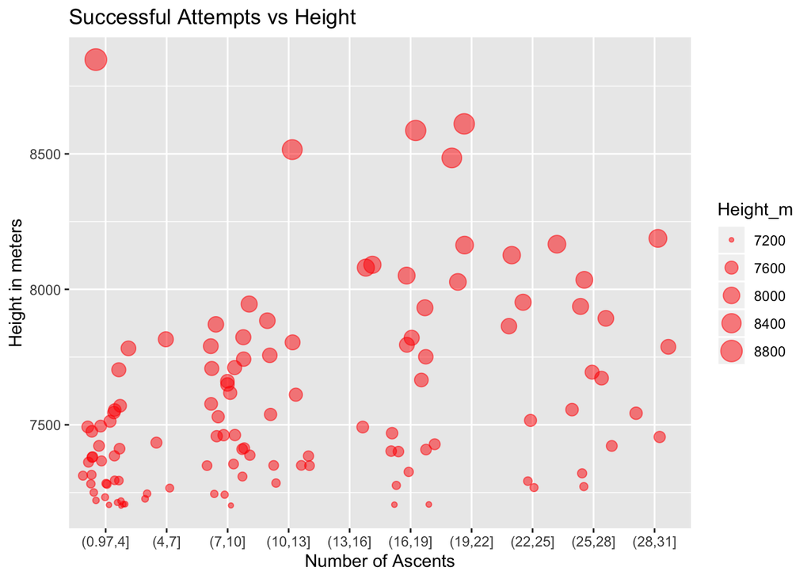

##Top 10 mountains most difficult to climb So to figure out what is a cause for failed attempted peaks other than heights, I think a could question to ask is how difficult the climb is.I determined that a mountain is difficult to climb by, the total number of failed attempts dived by the number of total climbs. The people who have failed out of the total attempts seem like a could measure for difficulty.

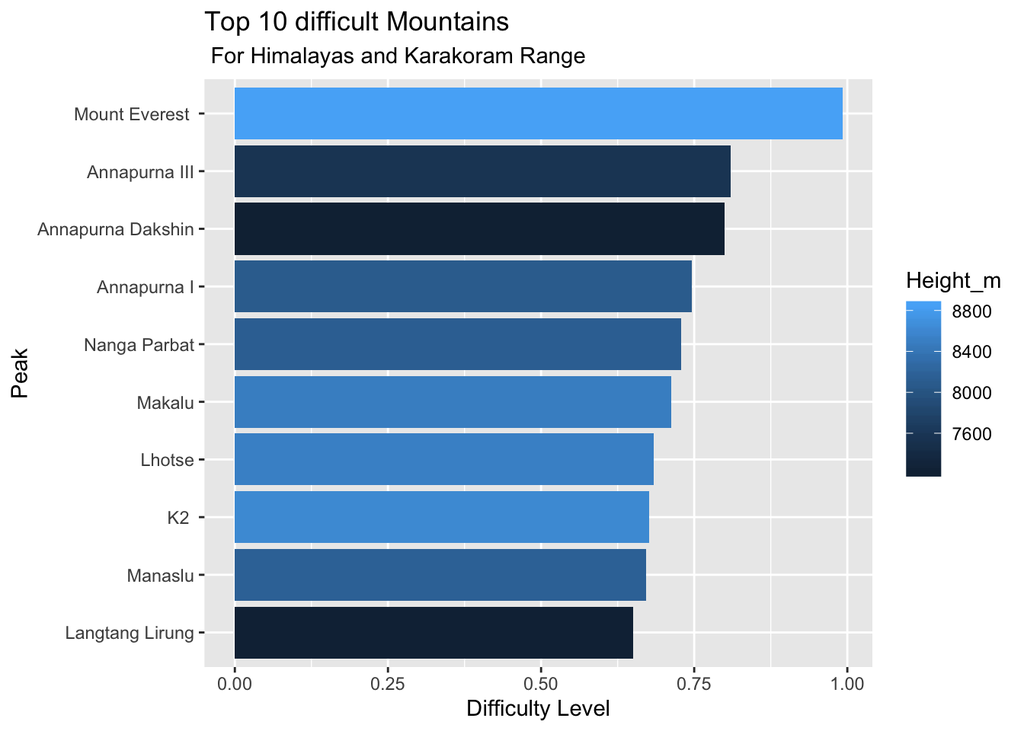

```r
# bar graph of top 10 difficult mountains to climb from the Himalayas and Karakoram ranges.
ggplot(mtn, aes(x = reorder(mtn$Peak, mtn$Difficulty), y = mtn$Difficulty, fill = Height_m)) +
  geom_bar(stat = "identity") +
  coord_flip() +labs(y="Difficulty Level", x="Peak")+
  ggtitle("Top 10 difficult Mountains  ",
          subtitle = " For Himalayas and Karakoram Range")
```

## Difficult grading scale

```
## # A tibble: 6 x 5
##   Peak              Height_m  Rank success_rate difficult_level
##   <chr>                <int> <int>        <dbl> <chr>
## 1 Mamostong Kangri      7516    47          100 Easy
## 2 Saser Kangri II E     7513    48          100 Easy
## 3 Saser Kangri III      7495    51          100 Easy
## 4 Passu Sar             7476    54          100 Easy
## 5 Teram Kangri I        7462    56          100 Easy
## 6 Sia Kangri            7422    63          100 Easy
```

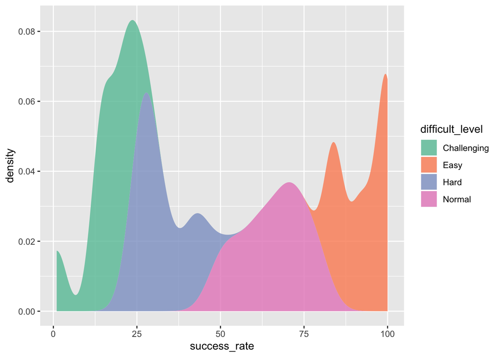

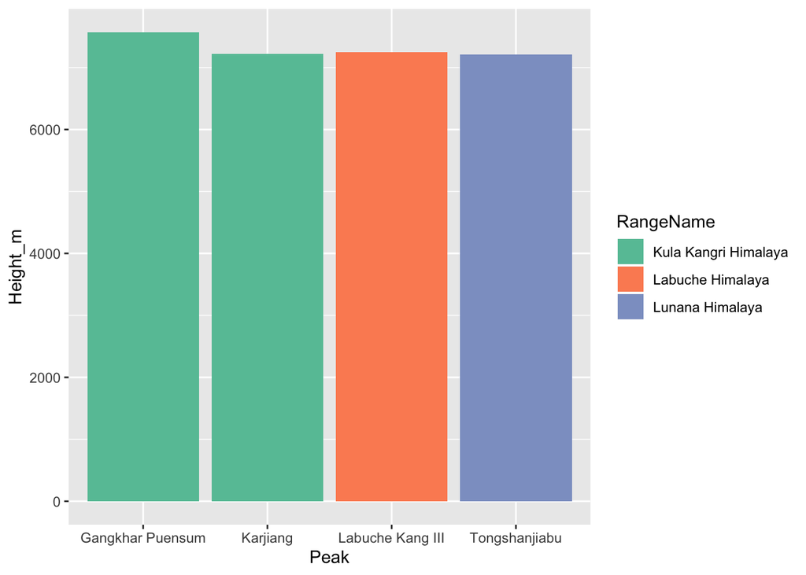

```r
unclimb<-summits %>% filter(Year_First_Ascent=="unclimbed")%>%select(Peak, Height_m,RangeName)
ggplot(data=unclimb,aes(x=Peak,y=Height_m,fill=RangeName))+geom_bar(stat="identity")+scale_fill_brewer(palette = "Set2")
```

Also, by looking at the plot and insight can be made about unclimed mountains.Based of the chart, the unclimbed peaks would be inbetween the range of easy and normal, with a success rate of 75-100%. So this analysis is particularly good for any climber who is seeking to set a record as being the first to summit any one of these unclimbed peaks, and has a good chance at doing so.

Let’s look at other factors such as season to see if this is the case. * Note that these mountains are in the Himalayas and Karakoram range.

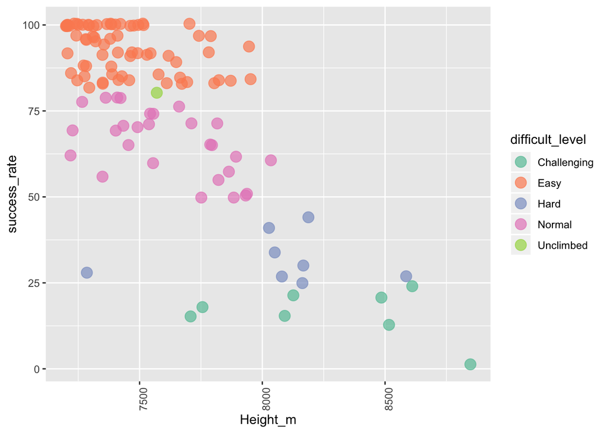

**I Joined the season_death data frame and the successrate data frame to find new insights**

```r
New_facts<-inner_join(season_death,successrate,by="Peak")
kable(head(New_facts))
```

| Year.of.Death | Season | Peak | Fatalities | Nationality | Number.of.Females | Height_m | Rank | Ascent | Failed_attempts | total_attempts | success_rate | difficult_level |
| --- | --- | --- | --- | --- | --- | --- | --- | --- | --- | --- | --- | --- |
| 1972 | PRE MONSOON | Manaslu | 4 | Korean | 0 | 8163 | 8 | 15 | 45 | 60 | 25 | Hard |
| 1972 | PRE MONSOON | Manaslu | 1 | Japanese | 0 | 8163 | 8 | 15 | 45 | 60 | 25 | Hard |
| 1972 | PRE MONSOON | Manaslu | 10 | Nepalese Sherpa | 0 | 8163 | 8 | 15 | 45 | 60 | 25 | Hard |
| 1972 | PRE MONSOON | Manaslu | 2 | Austrian | 0 | 8163 | 8 | 15 | 45 | 60 | 25 | Hard |
| 1937 | SUMMER | Nanga Parbat | 7 | German | 0 | 8126 | 9 | 18 | 67 | 85 | 21 | Challenging |
| 1937 | SUMMER | Nanga Parbat | 9 | Indian Sherpa | 0 | 8126 | 9 | 18 | 67 | 85 | 21 | Challenging |

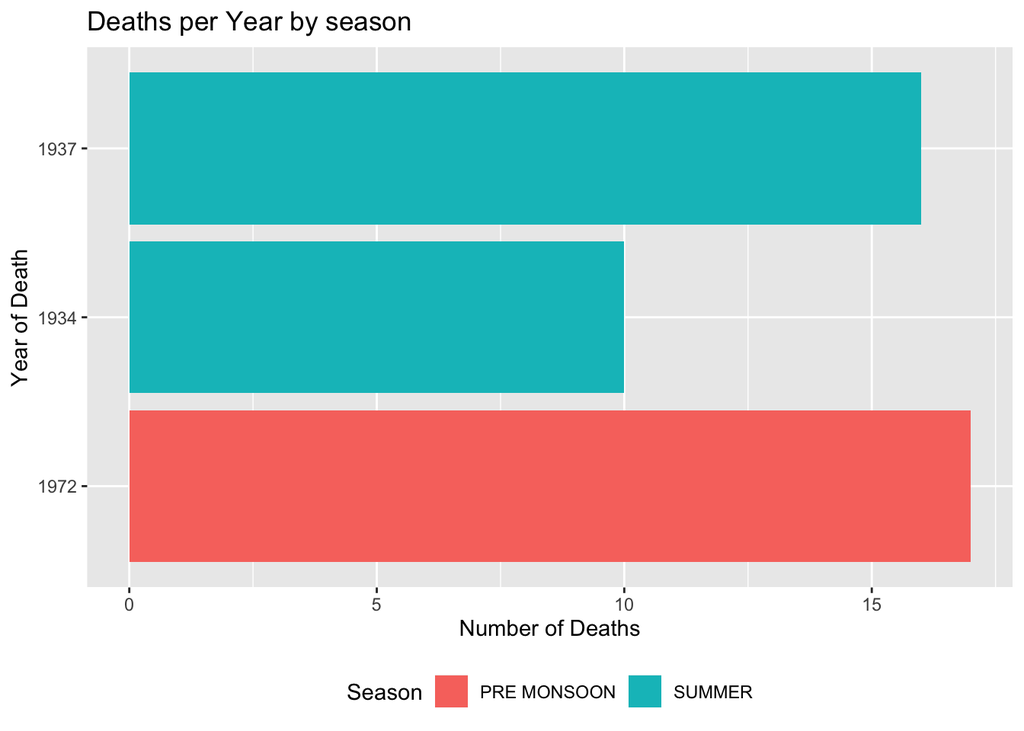

```r
ggplot(data = New_facts, aes(x=reorder(Year.of.Death,Fatalities),y=Fatalities, fill=Season))+
geom_bar(stat = "identity") +
  coord_flip() +theme(legend.position = "bottom") + labs(x="Year of Death", y="Number of Deaths")+
  ggtitle("Deaths per Year by season")
```

# Summary

This analysis is intended to assist climbers to make a well informed judgement on what peaks will lead to successful summits based on the data provided. Backed by visual representations the emphasis of this analysis is to prevent any unforeseen events that may lead to fatalities that can be preventable. Hopefully decisions as to what peaks to choose from can be made from the analysis and visulization of this project.

**Insights** Turns out according to my analysis, Mountains that are the most difficult to climb are not neccessarily ,although common,the tallest.

Also,the time of the year has an affect on the climber success rate. More climbers died in summer than in pre-moonsoon and much later in the years. It would been great if i could have had information on the cause of the death as that would make my analysis more insightful.

This analysis was limited by climber data such as , age, gender, skillset. We know that there is a bias in the data because beginners don’t climb Everest as their first climb. So I would like to add the skillset of climbers to be joined to the previous data and see if there is indeed a bias as I suspect.

Next, I would like to incorporate data from climbers on the reason for the failed attempt and the cause of death as it may provide a deeper insight to where the problems lie. I believe that those missing pieces of information could explain as to why there are more deaths as the years go one , and when technology and equipment should be better.